[figure not shown]

# UNIVERSIDAD SIMÓN BOLÍVAR Departamento de Tecnología y Electrónica EC7817 - Tópico especial II: Inteligencia Artificial en Biomédica

### Autor: William Chacón Profesor: Miguel Altuve

Junio, 2022

```python
import numpy as np
#import csv
#import pandas as pd
import matplotlib.pyplot as plt
import matplotlib.cbook as cbook
#import statistics as stats

import scipy
from scipy import stats
#from scipy.stats import boxcox
#from scipy.special import inv_boxcox

import sklearn
import sklearn.model_selection as sklms
import sklearn.linear_model as skllm
import sklearn.metrics as sklmt
#from sklearn import cross_validation
#import sklearn.cross_validation as sklcv

#format of print for numpy float
np.set_printoptions(formatter={'float': lambda x: "{0:0.4f}".format(x)})
```

# Taller 1

En el presente notebook se procede a realizar una estudio del dataset entregado.

Primero se inicia con la importación de los datos para su futuro pre-procesamiento.

```python
file = np.loadtxt("abalone.data", dtype = str, delimiter =",")

print(file)
```

```
[['M' '0.455' '0.365' ... '0.101' '0.15' '15']
 ['M' '0.35' '0.265' ... '0.0485' '0.07' '7']
 ['F' '0.53' '0.42' ... '0.1415' '0.21' '9']
 ...
 ['M' '0.6' '0.475' ... '0.2875' '0.308' '9']
 ['F' '0.625' '0.485' ... '0.261' '0.296' '10']
 ['M' '0.71' '0.555' ... '0.3765' '0.495' '12']]
```

```python
print("Data file size is: (" + str(np.size(file[:][:],0)) + "," + str(np.size(file[:][:],1)) + ")")
```

```
Data file size is: (4177,9)
```

```python
varnames = np.array(['Sex', 'Length', 'Diameter', 'Height', 'Whole_weight', 'Shucked_weight', 'Viscera_weight', 'Shell_weight', 'Rings'])


data = np.vstack( (varnames, file) )

print(data)
```

```
[['Sex' 'Length' 'Diameter' ... 'Viscera_weight' 'Shell_weight' 'Rings']
 ['M' '0.455' '0.365' ... '0.101' '0.15' '15']
 ['M' '0.35' '0.265' ... '0.0485' '0.07' '7']
 ...
 ['M' '0.6' '0.475' ... '0.2875' '0.308' '9']
 ['F' '0.625' '0.485' ... '0.261' '0.296' '10']
 ['M' '0.71' '0.555' ... '0.3765' '0.495' '12']]
```

```python
print("Data array size is: (" + str(np.size(data[:][:],0)) + "," + str(np.size(data[:][:],1)) + ")")
```

```
Data array size is: (4178,9)
```

A continuación, se procede a transformar los valores M, F e I del atributo 'sex' en 1, 0 y -1 respectivamente. De esta forma, se tendrán valores numéricos para todos los atributos de cada muestra del conjunto de datos. Con esto, se procede a convertir todos los valores del arreglo, que actualmente son strings, a números, floats.

```python
file[ file[ : , 0 ] == 'M'  , 0 ] = 1
file[ file[ : , 0 ] == 'F'  , 0 ] = 0
file[ file[ : , 0 ] == 'I'  , 0 ] = -1
```

```python
print(file)
```

```
[['1' '0.455' '0.365' ... '0.101' '0.15' '15']
 ['1' '0.35' '0.265' ... '0.0485' '0.07' '7']
 ['0' '0.53' '0.42' ... '0.1415' '0.21' '9']
 ...
 ['1' '0.6' '0.475' ... '0.2875' '0.308' '9']
 ['0' '0.625' '0.485' ... '0.261' '0.296' '10']
 ['1' '0.71' '0.555' ... '0.3765' '0.495' '12']]
```

```python
data2 = file.astype( float );
print(data2)
```

```
[[1.0000 0.4550 0.3650 ... 0.1010 0.1500 15.0000]
 [1.0000 0.3500 0.2650 ... 0.0485 0.0700 7.0000]
 [0.0000 0.5300 0.4200 ... 0.1415 0.2100 9.0000]
 ...
 [1.0000 0.6000 0.4750 ... 0.2875 0.3080 9.0000]
 [0.0000 0.6250 0.4850 ... 0.2610 0.2960 10.0000]
 [1.0000 0.7100 0.5550 ... 0.3765 0.4950 12.0000]]
```

Teniendo el arreglo de números, se procede a determinar todas las variables estadísticas de cada conjunto de datos asociados a cada uno de los atributos.

```python
#histData2 = [ np.histogram(data2[:,0]), np.histogram(data2[:,1]), np.histogram(data2[:,2]), np.histogram(data2[:,3]), np.histogram(data2[:,4]), np.histogram(data2[:,5]), np.histogram(data2[:,6]), np.histogram(data2[:,7]), np.histogram(data2[:,8])]
#print(histData2)
```

## Análisis Estadístico

Inicializando variables de interés

```python
#Parámetros estadísticos de interés para los 9 atributos del arreglo

#Inicialización

DataMean = np.zeros((9,1))       #media
DataMedian = np.zeros((9,1))     #mediana
DataMode = np.zeros((9,1))       #moda
DataMax = np.zeros((9,1))        #máximo
DataMin = np.zeros((9,1))        #mínimo
DataRange = np.zeros((9,1))      #rango
DataDesv = np.zeros((9,1))       #desviación
DataSkew = np.zeros((9,1))       #asimetría
DataKurt = np.zeros((9,1))       #curtosis
```

```python
#cálculo de los parámetros estadísticos

DataMean = np.mean(data2, axis = 0)
DataMedian = np.median(data2, axis = 0)
DataMode = stats.mode(data2, axis = 0)
DataMax = np.max(data2, axis = 0)
DataMin = np.min(data2, axis = 0)
DataRange = DataMax - DataMin
DataDesv = np.std(data2, axis = 0)
DataSkew = stats.skew(data2, axis = 0, bias = 0)
DataKurt = stats.kurtosis(data2, axis = 0, bias = 0)
```

```python
#Presentación de los valores de los parámetros estadísticos estudiados

print('la media de los atributos es:');
print(DataMean);
print();
print('la mediana de los atributos es:');
print(DataMedian);
print();
print('la moda de los atributos es:');
print(DataMode);
print();
print('el valor máximo de los atributos es:');
print(DataMax);
print();
print('el valor mínimo de los atributos es:');
print(DataMin);
print();
print('lel rango de los atributos es:');
print(DataRange);
print();
print('la desviación estándar de los atributos es:');
print(DataDesv);
print();
print('la asimetría de los atributos es:');
print(DataSkew);
print();
print('el curtosis de los atributos es:');
print(DataKurt);
print();
```

```
la media de los atributos es:
[0.04452957 0.5239921  0.40788125 0.1395164  0.82874216 0.35936749
 0.18059361 0.23883086 9.93368446]

la mediana de los atributos es:
[0.     0.545  0.425  0.14   0.7995 0.336  0.171  0.234  9.    ]

la moda de los atributos es:
ModeResult(mode=array([[1.    , 0.55  , 0.45  , 0.15  , 0.2225, 0.175 , 0.1715, 0.275 ,
        9.    ]]), count=array([[1528,   94,  139,  267,    8,   11,   15,   43,  689]]))

el valor máximo de los atributos es:
[ 1.      0.815   0.65    1.13    2.8255  1.488   0.76    1.005  29.    ]

el valor mínimo de los atributos es:
[-1.0e+00  7.5e-02  5.5e-02  0.0e+00  2.0e-03  1.0e-03  5.0e-04  1.5e-03
  1.0e+00]

lel rango de los atributos es:
[ 2.      0.74    0.595   1.13    2.8235  1.487   0.7595  1.0035 28.    ]

la desviación estándar de los atributos es:
[0.8277156  0.12007854 0.09922799 0.04182205 0.49033031 0.22193638
 0.10960113 0.13918601 3.22378307]

la asimetría de los atributos es:
[-0.0830555  -0.63987327 -0.60919814  3.12881738  0.53095856  0.71909792
  0.59185215  0.62092683  1.1141019 ]

el curtosis de los atributos es:
[-1.53607188e+00  6.46209739e-02 -4.54755814e-02  7.60255092e+01
 -2.36435043e-02  5.95123678e-01  8.40117490e-02  5.31926126e-01
  2.33068743e+00]
```

```python
# Obtención de variables de IQR

DataQ1 = np.percentile(data2, 25, axis = 0)
DataQ2 = np.percentile(data2, 50, axis = 0)
DataQ3 = np.percentile(data2, 75, axis = 0)

DataIQR = stats.iqr(data2, axis = 0)
```

```python
#Presentación de los parámetros IQR

print('Q1 de los atributos es:');
print(DataQ1);
print();
print('Q2 de los atributos es:');
print(DataQ2);
print();
print('Q3 de los atributos es:');
print(DataQ3);
print();
print('IQR de los atributos es:');
print(DataIQR);
print();
```

```
Q1 de los atributos es:
[-1.      0.45    0.35    0.115   0.4415  0.186   0.0935  0.13    8.    ]

Q2 de los atributos es:
[0.     0.545  0.425  0.14   0.7995 0.336  0.171  0.234  9.    ]

Q3 de los atributos es:
[ 1.     0.615  0.48   0.165  1.153  0.502  0.253  0.329 11.   ]

IQR de los atributos es:
[2.     0.165  0.13   0.05   0.7115 0.316  0.1595 0.199  3.    ]
```

Es importante destacar que los atributos 'sex' (argumento 0) y 'number of rings' (argumento 8) son valores de naturaleza discreta, por lo que carece de sentido hablar de los parámetros estadísticos anteriormente calculados.

Siguiendo este orden de ideas, los valores correspondientes a los parámetros estadísticos calculados previamente para los atributos mencionados serán obviados.

Adicionalmente, tampoco se realizará un análisis o preprocesamiento de los mismos (inicialmente se consideró el normalizar el atributo de número de anillos, pero como el mismo representa el resultado que se pretende estimar con la regresión lineal, para las primeras pruebas no se realizará la normalización).

A continuación, se realizará un estudio del comportamiento de los atributos de variables continuas.

### Análisis estadístico de los atributos

Primero se comenzará con los histogramas de cada una de las variables continuas.

Atributo 'Length'

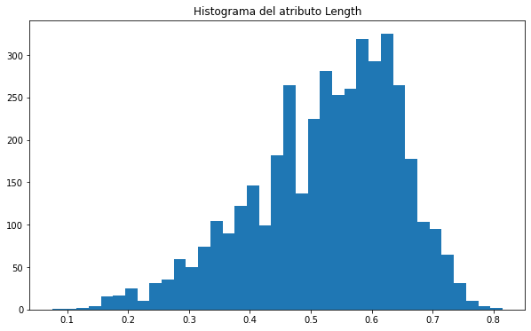

```python
#np.histogram( data2[:,1] )

fig = plt.figure(figsize =(10, 6))
plt.hist( data2[:,1] , bins = 'auto' );
plt.title('Histograma del atributo Length');
```

Atributo 'Diameter'.

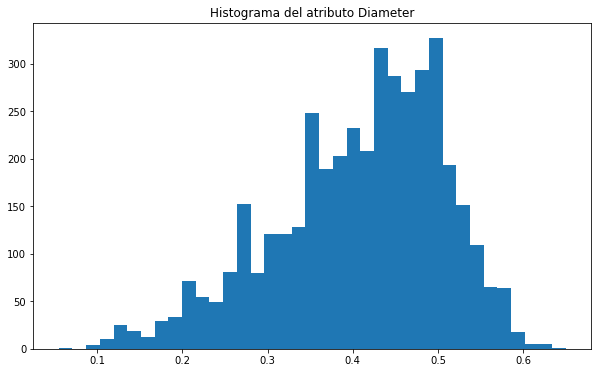

```python
#np.histogram( data2[:,2] )

fig = plt.figure(figsize =(10, 6))
plt.hist( data2[:,2] , bins = 'auto' );
plt.title('Histograma del atributo Diameter');
```

Atributo 'Height'

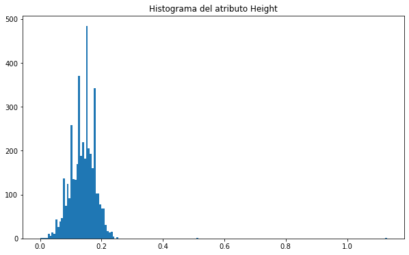

```python
#np.histogram( data2[:,3] )

fig = plt.figure(figsize =(10, 6))
plt.hist( data2[:,3] , bins = 'auto' );
plt.title('Histograma del atributo Height');
```

Atributo 'Whole_weight'

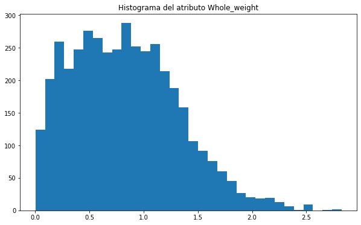

```python
#np.histogram( data2[:,4] )

fig = plt.figure(figsize =(10, 6))
plt.hist( data2[:,4] , bins = 'auto' );
plt.title('Histograma del atributo Whole_weight');
```

Atributo 'Shucked_weight'

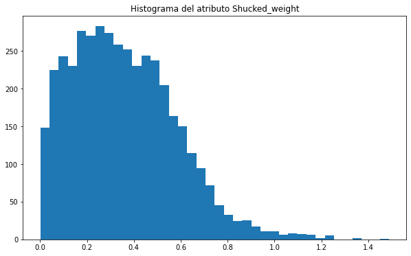

```python
#np.histogram( data2[:,5] )

fig = plt.figure(figsize =(10, 6))
plt.hist( data2[:,5] , bins = 'auto' );
plt.title('Histograma del atributo Shucked_weight');
```

Atributo 'Visera_weight'

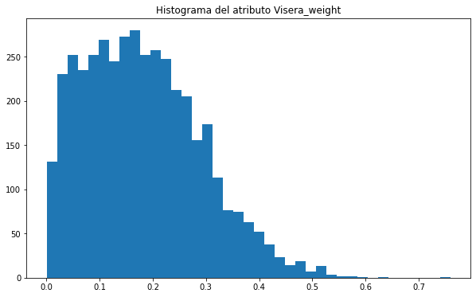

```python
#np.histogram( data2[:,6] )

fig = plt.figure(figsize =(10, 6))
plt.hist( data2[:,6] , bins = 'auto' );
plt.title('Histograma del atributo Visera_weight');
```

Atributo 'Shell_weight'

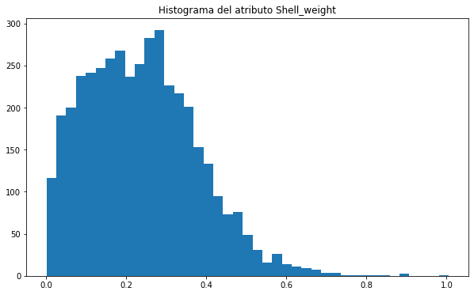

```python
#np.histogram( data2[:,7] )

fig = plt.figure(figsize =(10, 6))
plt.hist( data2[:,7] , bins = 'auto' );
plt.title('Histograma del atributo Shell_weight');
```

Ahora se procede a presentar los diagramas inter-quartil (IQR) de los atributos de variable continua.

### Extracción de las muestras con valores atípicos

Es importante mencionar que se selecciona el IQR como criterio para la detección de valores atípicos dentro de los datos ya que el mismo proporciona un rango más estrecho para los datos que el criterio de la $ \mu \pm 3 \sigma $.

[figure not shown]

Figura 1: Esquema de la distribución e identificación de valores atípicos mediante IQR

fuente de la figura: https://towardsdatascience.com/create-and-customize-boxplots-with-pythons-matplotlib-to-get-lots-of-insights-from-your-data-d561c9883643?gi=c740821c406a

```python
stats2 = cbook.boxplot_stats(data2[:, 1:8 ], labels = varnames[1:8])
```

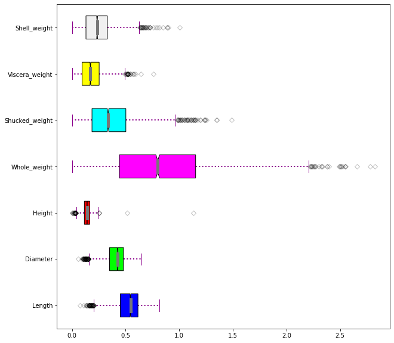

```python
#fig, ax = plt.subplots(1, 1)
fig = plt.figure(figsize =(10, 10))
ax = fig.add_subplot(111)

# Plot boxplots from our computed statistics
bp = ax.bxp([stats2[i] for i in range(7)], positions=range(7), patch_artist = True, vert = 0, shownotches ='True');



colors = ['#0000FF', '#00FF00', '#FF0000', '#FF00FF', '#00FFFF', '#FFFF00', '#F0F0F0']

for patch, color in zip(bp['boxes'], colors):
    patch.set_facecolor(color)

# changing color and linewidth of
# whiskers
for whisker in bp['whiskers']:
    whisker.set(color ='#8B008B',
                linewidth = 2,
                linestyle =":")

# changing color and linewidth of
# caps
for cap in bp['caps']:
    cap.set(color ='#8B008B',
            linewidth = 1)

# changing color and linewidth of
# medians
for median in bp['medians']:
    median.set(color ='#777777',
               linewidth = 5)

# changing style of fliers
for flier in bp['fliers']:
    flier.set(marker ='D',
              color ='#e7298a',
              alpha = 0.25)
```

Como se puede apreciar, existen una cantidad considerable de valores atípicos de acuerdo al estudio de IQR mostrado anteriormente.

Las muestras que presenten algún valor atípico en cualquiera de los atributos presentados anteriormente deben de ser removidos, de modo que no influencien negativamente el proceso de estimación de comportamiento.

A continuación, se procede a remover los valores atípicos según el criterio establecido.

```python
#Detector de valores atípicos por debajo del límite inferior
aux1 = data2 < ( DataQ1 - 1.5 * DataIQR ) * np.ones( (np.size(data2,0),np.size(data2,1)) )
aux1 = np.sum(aux1, axis = 1)
```

```python
#Detector de valores atípicos por encima del límite supeior
aux2 = data2 > ( DataQ3 + 1.5 * DataIQR ) * np.ones( (np.size(data2,0),np.size(data2,1)) )
aux2 = np.sum(aux2, axis = 1)
```

```python
#Cantidad de atributos cuyo valor es inferior al mínimo valor aceptable como típico
sum(aux1 != 0)
```

```
66
```

```python
#Cantidad de atributos cuyo valor es supeior al máximo valor aceptable como típico
sum(aux2 != 0)
```

```
330
```

```python
#Extracción de las muestras con valores atípicos
data3 = data2[ (aux1 == 0) & (aux2 == 0), :]
```

Cantidad de Muestras Restantes

```python
#Cantidad de muestras restantes
np.size(data3,0)
```

```
3781
```

Cantidad de muestras extraidas de la data

```python
#Cantidad de muestras con valores removidas
np.size(data2,0) - np.size(data3,0)
```

```
396
```

Si se realiza una comparación, se aprecia que la cantidad de muestras descartadas por poseer valores atípicos representa un 9.48% de la data original, dejando solo un 90.52% de la data como muestras apropiadas para efectuar la regresión.

No obstante, más del 90% de las muestras en una data de más de 4170 muestras es una cantidad aceptable para relaizar una primera predicción (iteración) del comportamiento de la Abalone.

```python
print("Porcentaje de muestras removidas = " + str( ( np.size(data2,0) - np.size(data3,0) ) / np.size(data2,0) *100 ))
print("Porcentaje de muestras restantes = " + str( np.size(data3,0) / np.size(data2,0) *100 ))
```

```
Porcentaje de muestras removidas = 9.480488388795786
Porcentaje de muestras restantes = 90.51951161120422
```

Una vez removido los valores atípicos, se tienen 3781 muestras restantes con las cuales realizar la regresión lineal para predecir la edad del Abulón.

A continuación, se procede a realizar los preprocesamientos apropiados de los datos para asegurar un buen desempeño en durante el proceso de estimación.

### Análisis estadístico de las muestras con valores típicos

Primero se debe visualizar el comportamiento estadístico de las variables de interés sin los valores atípicos.

Atributo 'Lenght'.

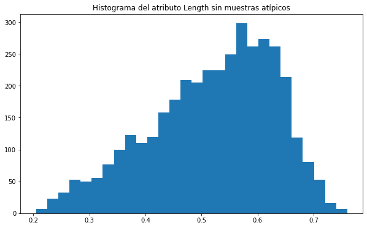

```python
fig = plt.figure(figsize =(10, 6))
plt.hist( data3[:,1] , bins = 'auto' );
plt.title('Histograma del atributo Length sin muestras atípicos');
```

Atributo 'Diameter'.

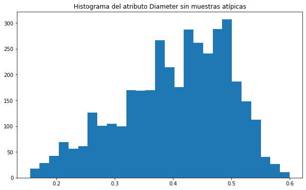

```python
fig = plt.figure(figsize =(10, 6))
plt.hist( data3[:,2] , bins = 'auto' );
plt.title('Histograma del atributo Diameter sin muestras atípicas');
```

Atributo 'Height'.

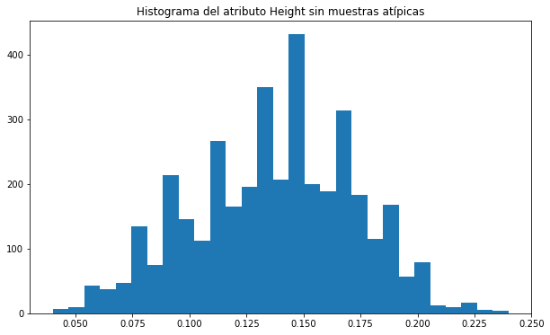

```python
fig = plt.figure(figsize =(10, 6))
plt.hist( data3[:,3] , bins = 'auto' );
plt.title('Histograma del atributo Height sin muestras atípicas');
```

Atributo 'Whole_weight'.

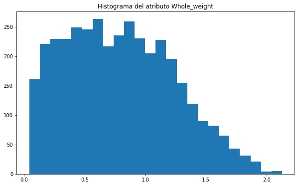

```python
fig = plt.figure(figsize =(10, 6))
plt.hist( data3[:,4] , bins = 'auto' );
plt.title('Histograma del atributo Whole_weight');
```

Atributo 'Shucked_weight'.

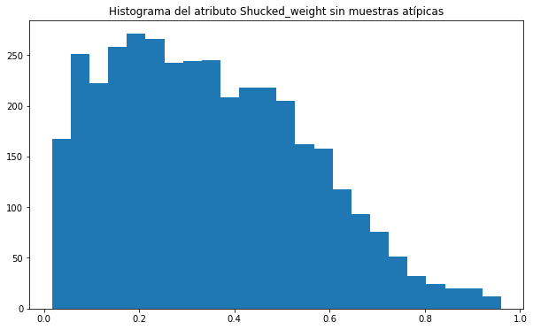

```python
fig = plt.figure(figsize =(10, 6))
plt.hist( data3[:,5] , bins = 'auto' );
plt.title('Histograma del atributo Shucked_weight sin muestras atípicas');
```

Atributo 'Visera_weight'.

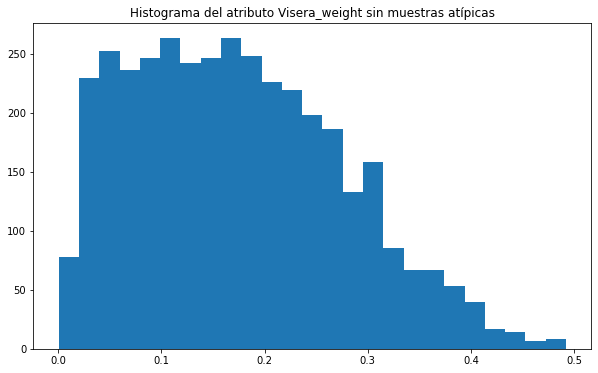

```python
fig = plt.figure(figsize =(10, 6))
plt.hist( data3[:,6] , bins = 'auto' );
plt.title('Histograma del atributo Visera_weight sin muestras atípicas');
```

Atributo 'Shell_weight'.

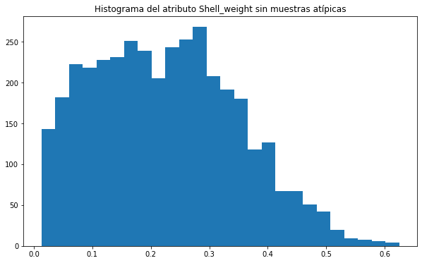

```python
fig = plt.figure(figsize =(10, 6))
plt.hist( data3[:,7] , bins = 'auto' );
plt.title('Histograma del atributo Shell_weight sin muestras atípicas');
```

Claramente, los datos presentan comportamientos que discrepan de la tendencia de una distribución gaussiana. Por lo mismo, se plantea el transformar los datos.

### Transformación de datos

Ahora se procede a transformar los datos para asegurar un comportamiento Gaussiano de la distribución de valores de todos los atributos continuos en aquellos donde no se presente un valor similar a una distribución Gaussiana.

En este caso las variables a transformar son todas asociadas a los pesos (weights): Whole_weight, Shucked_weight, Visera_weight, Shell_weight.

### $\rightarrow$ Transformación raíz cuadrada

Primero se considera implementar una transformación de raíz cuadrada para todas estas variables.

\begin{align*} u = \sqrt{y} \end{align*}

```python
#data4 = np.empty_like(data3)
#data4[:,:] = data3

data4 = np.copy(data3)

data4[:,4] = np.sqrt(data4[:,4])
data4[:,5] = np.sqrt(data4[:,5])
data4[:,6] = np.sqrt(data4[:,6])
data4[:,7] = np.sqrt(data4[:,7])
```

Atributo Whole_weight transformado con raíz cuadrada

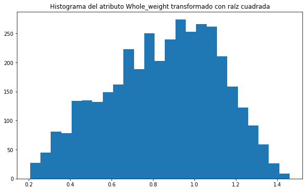

```python
fig = plt.figure(figsize =(10, 6))
plt.hist( data4[:,4] , bins = 'auto' );
plt.title('Histograma del atributo Whole_weight transformado con raíz cuadrada')
plt.show()
```

Atributo Shucked_weight transformado con raíz cuadrada

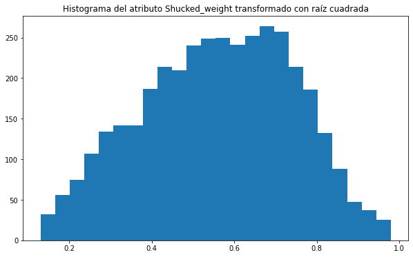

```python
fig = plt.figure(figsize =(10, 6))
plt.hist( data4[:,5] , bins = 'auto' );
plt.title('Histograma del atributo Shucked_weight transformado con raíz cuadrada')
plt.show()
```

Atributo Visera_weight transformado con raíz cuadrada.

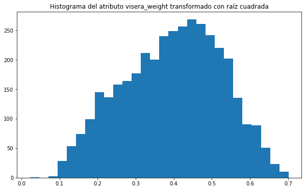

```python
fig = plt.figure(figsize =(10, 6))
plt.hist( data4[:,6] , bins = 'auto' );
plt.title('Histograma del atributo visera_weight transformado con raíz cuadrada')
plt.show()
```

Atributo Shell_weight transformado con raíz cuadrada.

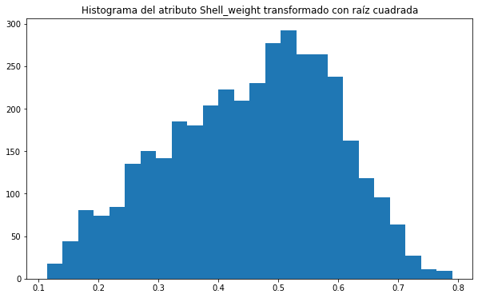

```python
fig = plt.figure(figsize =(10, 6))
plt.hist( data4[:,7] , bins = 'auto' );
plt.title('Histograma del atributo Shell_weight transformado con raíz cuadrada')
plt.show()
```

### $\rightarrow$ Transformación logarítmica

Ahora se considera implementar en los mismos atributos una transformación logaritmica.

\begin{align*} u = \ln{y} \end{align*}

```python
#data5 = np.empty_like(data3)
#data5[:,:] = data3

data5 = np.copy(data3)

data5[:,4] = np.log(data5[:,4])
data5[:,5] = np.log(data5[:,5])
data5[:,6] = np.log(data5[:,6])
data5[:,7] = np.log(data5[:,7])
```

Atributo Whole_weight transformado con logaritmo neperiano.

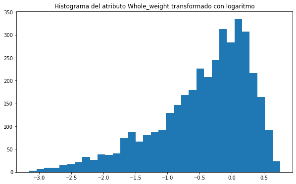

```python
fig = plt.figure(figsize =(10, 6))
plt.hist( data5[:,4] , bins = 'auto' );
plt.title('Histograma del atributo Whole_weight transformado con logaritmo')
plt.show()
```

Atributo Shucked_weight transformado con logaritmo neperiano.

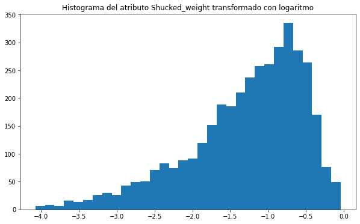

```python
fig = plt.figure(figsize =(10, 6))
plt.hist( data5[:,5] , bins = 'auto' );
plt.title('Histograma del atributo Shucked_weight transformado con logaritmo')
plt.show()
```

Atributo Visera_weight transformado con logaritmo neperiano.

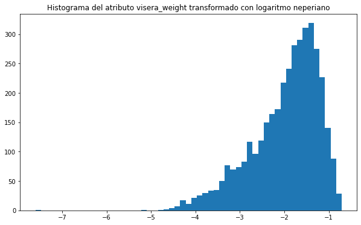

```python
fig = plt.figure(figsize =(10, 6))
plt.hist( data5[:,6] , bins = 'auto' );
plt.title('Histograma del atributo visera_weight transformado con logaritmo neperiano')
plt.show()
```

Atributo Shell_weight transformado con logaritmo neperiano.

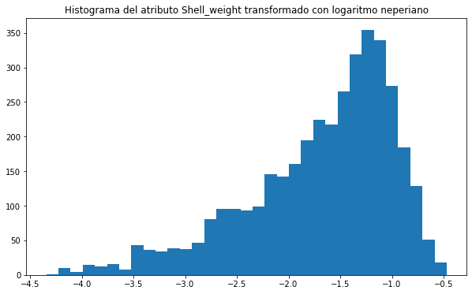

```python
fig = plt.figure(figsize =(10, 6))
plt.hist( data5[:,7] , bins = 'auto' );
plt.title('Histograma del atributo Shell_weight transformado con logaritmo neperiano')
plt.show()
```

\begin{align*} u = e^{y} \end{align*}

```python
#data6 = np.empty_like(data3)
#data6[:,:] = data3

data6 = np.copy(data3)

data6[:,4] = np.exp(data5[:,4])
data6[:,5] = np.exp(data5[:,5])
data6[:,6] = np.exp(data5[:,6])
data6[:,7] = np.exp(data5[:,7])
```

Atributo Whole_weight transformado con exponencial.

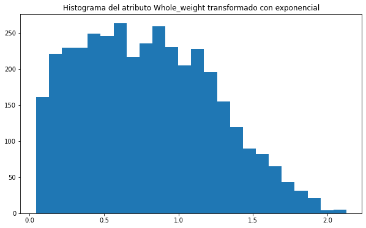

```python
fig = plt.figure(figsize = (10, 6))
plt.hist( data6[:,4] , bins = 'auto' );
plt.title('Histograma del atributo Whole_weight transformado con exponencial')
plt.show()
```

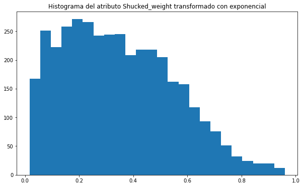

```python
fig = plt.figure(figsize = (10, 6))
plt.hist( data6[:,5] , bins = 'auto' );
plt.title('Histograma del atributo Shucked_weight transformado con exponencial')
plt.show()
```

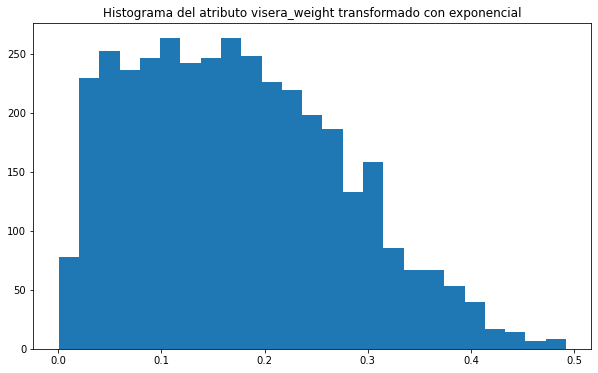

```python
fig = plt.figure(figsize = (10, 6))
plt.hist( data6[:,6] , bins = 'auto' );
plt.title('Histograma del atributo visera_weight transformado con exponencial')
plt.show()
```

Atributo Shell_weight transformado con exponencial.

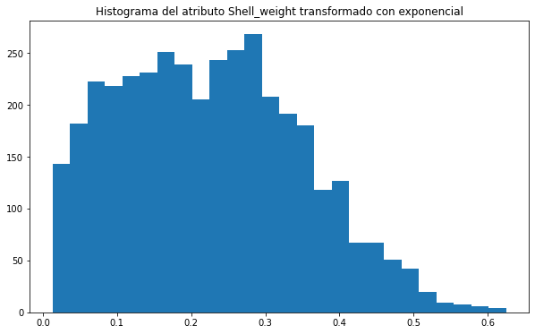

```python
fig = plt.figure(figsize = (10, 6))
plt.hist( data6[:,7] , bins = 'auto' );
plt.title('Histograma del atributo Shell_weight transformado con exponencial')
plt.show()
```

En búsqueda de obtener un conjunto de datos con una distribución aún más similar a una distribución gaussiana, se procede a implementar otra transformada a los datos.